# Examples Rprebas

francesco minunno

13 March 2018

## Rprebas package examples

This documents provides guidelines on Rprebas package installation and it shows some examples on how to run PREBAS forest model.

## Install the package

Go to the folder were the package is and install the package and load the library

Install the package

```r
# library(devtools)
# install_github("MikkoPeltoniemi/Rpreles")
# install_github("checcomi/Rprebas")
```

Load the packageg

```r
library(Rprebas)
```

## Function prebas

The function that calls the model is prebas(). See the help for a description of the input argumens and the outputs.

```r
?prebas
```

```
## starting httpd help server ... done
```

## Example 1

This first example uses the minimal inputs for the prebas function: the number of years of the simulations (nYears) and the weather inputs (PAR,TAir,VPD,Precip,CO2). In this example weather inputs are read from a .csv file

Read the weather input from an .csv file. To extract weather inputs from the LUKE database see “extractWeather” document.

```r
weather <- read.csv("inputs/weather.csv",header = T)
PAR = c(weather$PAR,weather$PAR,weather$PAR)
TAir = c(weather$TAir,weather$TAir,weather$TAir)
Precip = c(weather$Precip,weather$Precip,weather$Precip)
VPD = c(weather$VPD,weather$VPD,weather$VPD)
CO2 = c(weather$CO2,weather$CO2,weather$CO2)
DOY = c(weather$DOY,weather$DOY,weather$DOY)
```

Run the model

```r
PREBASout <- prebas(nYears = 100, PAR=PAR,TAir=TAir,VPD=VPD,Precip=Precip,CO2=CO2)
```

Plot model outputs

```r
# plot.prebas(PREBASout,layerNam = c("pine","spruce","birch"))
```

## Example 2

In this example PREBAS inputs are read from .csv files located in the “inputs” folder

Read the initial state of the stand (initVar), weather, site information (sietInfo), thinning and observed data (obsData).

```r
nYears = 100
siteInfo <- read.csv("inputs/siteInfo.csv",header = T)
thinning <- read.csv("inputs/Thinning.csv",header = T)
initVar <- read.csv("inputs/initVar.csv",header = T, row.names = 1)
obsData <- read.csv("inputs/obsData.csv",header = T)

weather <- read.csv("inputs/weather.csv",header = T)
PAR = c(weather$PAR,weather$PAR,weather$PAR)
TAir = c(weather$TAir,weather$TAir,weather$TAir)
Precip = c(weather$Precip,weather$Precip,weather$Precip)
VPD = c(weather$VPD,weather$VPD,weather$VPD)
CO2 = c(weather$CO2,weather$CO2,weather$CO2)
DOY = c(weather$DOY,weather$DOY,weather$DOY)
```

Run the model

```r
PREBASout <- prebas(
                   nYears=nYears,
                   pCROBAS = pCROB,
                   pPRELES = pPREL,
                   siteInfo = siteInfo,
                   thinning = thinning,
                   PAR=PAR,TAir=TAir,VPD=VPD,Precip=Precip,CO2=CO2,
                   P0=NA,
                   initVar = as.matrix(initVar),
                   defaultThin = 0.,
                   ClCut = 1.,
                   inDclct = NA,
                   inAclct = NA)
```

## Plot model outputs

The function to plot the prebas objects is plot.prebas

```r
?plot.prebas
```

Select some variables to plot

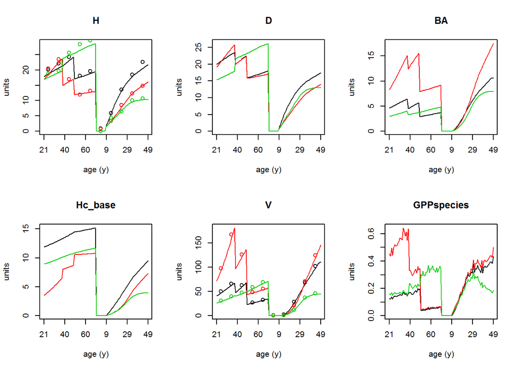

```r
variableIDs=c(11:14,30,44);siteIDs=NA;leg=T;layerNam = c("pine","spruce","birch")

plot.prebas(PREBASout,variableIDs,siteIDs,leg = F,layerNam =layerNam,obsData = obsData)
```